# Preliminary model robustness checks

Cumulative mortality and forest-community climate-niche change

## What these checks answer

The current preliminary model remains the reference model. These checks ask whether its disturbance coefficients depend on:

1. comparing different condition histories across life stages;
2. retaining conditions that occupy only part of a plot;
3. broad geographic differences among states;
4. representing site water deficit as cumulative exposure while also including survey duration.

They also test life-stage differences directly on identical histories. They do not introduce a new severity definition or replace cumulative mortality.

## Main findings

- All 18 disturbance coefficients whose baseline 95% interval excluded zero retained the same direction across every applicable check.
- All 18 remained below p = 0.05 with state effects, mean monthly CWD, and cumulative CWD without the separate survey-period term.
- 16 of those 18 remained below p = 0.05 when conditions were required to occupy at least 80% of the plot.
- On the smaller identical-history sample, 9 of the 10 supported life-stage coefficients remained below p = 0.05. Their loss of precision should not be read as proof of no effect.
- 6 of the 15 joint life-stage tests were below p = 0.05. These tests identify sapling-adult differences that are larger than expected from sampling uncertainty under the model.
- Even the state-effects models explain at most 1.06% of response variance. These remain weakly predictive, observational preliminary models.

## Reproduction check

The robustness script refit the approved models before changing anything. The largest absolute coefficient difference was 4.163336e-16 and the largest standard-error difference was 4.857226e-17.

## Are the life-stage samples different?

| Response | Histories shared by both stages | Sapling histories | Adult histories |
| --- | --- | --- | --- |
| Temperature CWM | 48,294 | 50,463 | 73,981 |
| Precipitation CWM | 48,294 | 50,463 | 73,981 |
| CWD CWM | 48,294 | 50,463 | 73,981 |

The common-history models remove sample-composition differences: saplings and adults are fit on the same condition histories for each response.

## Do life-stage coefficients actually differ?

| Response | Predictor | Common histories | Wald statistic | df | p |
| --- | --- | --- | --- | --- | --- |
| Temperature CWM | Fire mortality | 48,294 | 0.631 | 1 | 0.427 |
| Temperature CWM | Insect mortality | 48,294 | 0.025 | 1 | 0.876 |
| Temperature CWM | Disease mortality | 48,294 | 2.208 | 1 | 0.137 |
| Temperature CWM | Cumulative site CWD | 48,294 | 2.614 | 1 | 0.106 |
| Temperature CWM | Survey period | 48,294 | 0.061 | 1 | 0.805 |
| Precipitation CWM | Fire mortality | 48,294 | 1.422 | 1 | 0.233 |
| Precipitation CWM | Insect mortality | 48,294 | 4.064 | 1 | 0.0438 |
| Precipitation CWM | Disease mortality | 48,294 | 5.147 | 1 | 0.0233 |
| Precipitation CWM | Cumulative site CWD | 48,294 | 5.162 | 1 | 0.0231 |
| Precipitation CWM | Survey period | 48,294 | 0.131 | 1 | 0.717 |
| CWD CWM | Fire mortality | 48,294 | 0.317 | 1 | 0.573 |
| CWD CWM | Insect mortality | 48,294 | 3.978 | 1 | 0.0461 |
| CWD CWM | Disease mortality | 48,294 | 5.954 | 1 | 0.0147 |
| CWD CWM | Cumulative site CWD | 48,294 | 0.422 | 1 | 0.516 |
| CWD CWM | Survey period | 48,294 | 5.808 | 1 | 0.016 |

The test asks whether the sapling and adult coefficients are equal. A small p-value means the life-stage contrast is larger than expected from sampling uncertainty under this model.

| Response | Predictor | Comparison | Difference | 95% low | 95% high | p |
| --- | --- | --- | --- | --- | --- | --- |
| Temperature CWM | Fire mortality | Adults - Saplings | 0.0008505 | -0.001248 | 0.002949 | 0.427 |
| Temperature CWM | Insect mortality | Adults - Saplings | -0.0001383 | -0.001869 | 0.001592 | 0.876 |
| Temperature CWM | Disease mortality | Adults - Saplings | -0.00141 | -0.003271 | 0.0004499 | 0.137 |
| Temperature CWM | Cumulative site CWD | Adults - Saplings | 1.818e-06 | -3.86e-07 | 4.023e-06 | 0.106 |
| Temperature CWM | Survey period | Adults - Saplings | 0.0003179 | -0.002212 | 0.002848 | 0.805 |
| Precipitation CWM | Fire mortality | Adults - Saplings | -0.1036 | -0.2739 | 0.06666 | 0.233 |
| Precipitation CWM | Insect mortality | Adults - Saplings | 0.1127 | 0.003126 | 0.2222 | 0.0438 |
| Precipitation CWM | Disease mortality | Adults - Saplings | -0.1476 | -0.2751 | -0.02009 | 0.0233 |
| Precipitation CWM | Cumulative site CWD | Adults - Saplings | 0.0001718 | 2.359e-05 | 0.00032 | 0.0231 |
| Precipitation CWM | Survey period | Adults - Saplings | -0.02538 | -0.1628 | 0.112 | 0.717 |
| CWD CWM | Fire mortality | Adults - Saplings | 0.05072 | -0.1258 | 0.2273 | 0.573 |
| CWD CWM | Insect mortality | Adults - Saplings | -0.117 | -0.232 | -0.002026 | 0.0461 |
| CWD CWM | Disease mortality | Adults - Saplings | 0.1439 | 0.02831 | 0.2594 | 0.0147 |
| CWD CWM | Cumulative site CWD | Adults - Saplings | -5.763e-05 | -0.0002314 | 0.0001162 | 0.516 |
| CWD CWM | Survey period | Adults - Saplings | 0.1282 | 0.02394 | 0.2325 | 0.016 |

## Does condition spatial support matter?

The current analysis requires a condition to occupy at least 30% of the plot. The 80% check retains histories whose condition remains at least 80% of the plot through every interval. This tests whether partial-plot conditions are driving the preliminary relationships.

| Community group | 0.3 | 0.5 | 0.8 | 0.95 |
| --- | --- | --- | --- | --- |
| Adults | 76,320 | 73,127 | 52,466 | 47,989 |
| Combined saplings + adults | 76,791 | 73,547 | 52,680 | 48,171 |
| Saplings | 56,373 | 54,529 | 39,593 | 36,321 |

## Are the disturbance results stable?

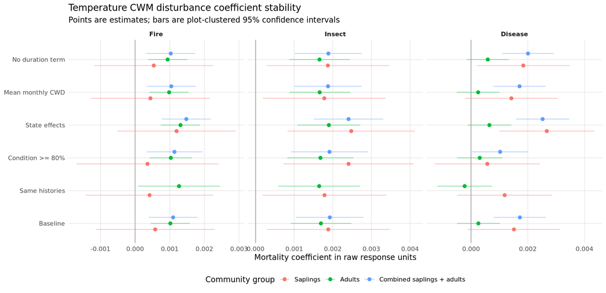

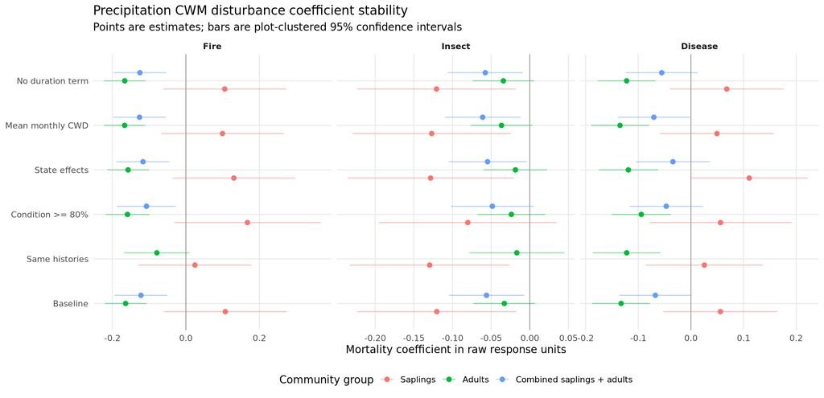

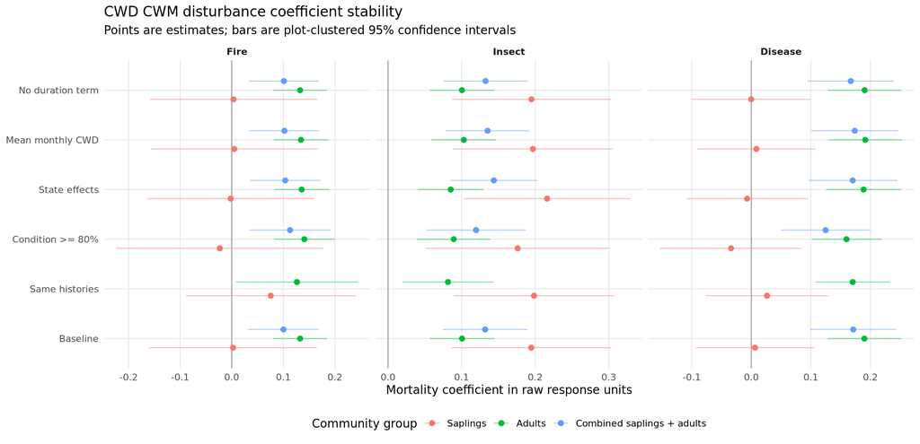

| Response | Community group | Disturbance coefficients | Stable sign | Sign changes |
| --- | --- | --- | --- | --- |
| CWD CWM | Combined saplings + adults | 3 | 3 | 0 |
| CWD CWM | Saplings | 3 | 1 | 2 |
| CWD CWM | Adults | 3 | 3 | 0 |
| Precipitation CWM | Combined saplings + adults | 3 | 3 | 0 |
| Precipitation CWM | Saplings | 3 | 3 | 0 |
| Precipitation CWM | Adults | 3 | 3 | 0 |
| Temperature CWM | Combined saplings + adults | 3 | 3 | 0 |
| Temperature CWM | Saplings | 3 | 3 | 0 |
| Temperature CWM | Adults | 3 | 2 | 1 |

## Cumulative CWD and survey duration

Three formulations are compared in the stability figure:

- the approved model with cumulative CWD and survey duration;
- mean monthly CWD and survey duration;
- cumulative CWD without a separate duration term.

The alternative formulations are diagnostics. Cumulative CWD remains the intended total-exposure predictor unless the collaborators choose otherwise.

## Interpretation

These are observational preliminary models with very low explained variance. Coefficient direction and uncertainty are more informative here than p-values alone. A stable coefficient is not automatically causal, and an unstable coefficient identifies a modeling or sampling dependency that should be resolved before final inference.